# Risk Factor Analysis

## Outcome Variable

**Outcome Variable:** pers_wasted624

## Predictor Variables

**Intervention Variable:** ever_stunted06

**Adjustment Set:**

- sex
- arm
- enstunt
- month
- brthmon
- vagbrth
- single
- W_gagebrth
- W_birthwt
- W_birthlen
- W_mage
- W_mhtcm
- W_meducyrs
- W_feducyrs
- W_parity
- delta_month
- delta_brthmon
- delta_vagbrth
- delta_single
- delta_W_gagebrth
- delta_W_birthwt
- delta_W_birthlen
- delta_W_mage
- delta_W_mhtcm
- delta_W_meducyrs
- delta_W_feducyrs
- delta_W_parity

## Stratifying Variables

The analysis was stratified on these variable(s):

- studyid
- country

## Data Summary

| studyid | country | ever_stunted06 | pers_wasted624 | n_cell | n |
| --- | --- | --- | --- | --- | --- |
| ki0047075b-MAL-ED | BANGLADESH | 0 | 0 | 145 | 240 |
| ki0047075b-MAL-ED | BANGLADESH | 0 | 1 | 10 | 240 |
| ki0047075b-MAL-ED | BANGLADESH | 1 | 0 | 77 | 240 |
| ki0047075b-MAL-ED | BANGLADESH | 1 | 1 | 8 | 240 |
| ki0047075b-MAL-ED | BRAZIL | 0 | 0 | 165 | 207 |
| ki0047075b-MAL-ED | BRAZIL | 0 | 1 | 2 | 207 |
| ki0047075b-MAL-ED | BRAZIL | 1 | 0 | 40 | 207 |
| ki0047075b-MAL-ED | BRAZIL | 1 | 1 | 0 | 207 |
| ki0047075b-MAL-ED | INDIA | 0 | 0 | 136 | 235 |
| ki0047075b-MAL-ED | INDIA | 0 | 1 | 14 | 235 |
| ki0047075b-MAL-ED | INDIA | 1 | 0 | 71 | 235 |
| ki0047075b-MAL-ED | INDIA | 1 | 1 | 14 | 235 |
| ki0047075b-MAL-ED | NEPAL | 0 | 0 | 192 | 235 |
| ki0047075b-MAL-ED | NEPAL | 0 | 1 | 1 | 235 |
| ki0047075b-MAL-ED | NEPAL | 1 | 0 | 41 | 235 |
| ki0047075b-MAL-ED | NEPAL | 1 | 1 | 1 | 235 |
| ki0047075b-MAL-ED | PERU | 0 | 0 | 147 | 270 |
| ki0047075b-MAL-ED | PERU | 0 | 1 | 0 | 270 |
| ki0047075b-MAL-ED | PERU | 1 | 0 | 121 | 270 |
| ki0047075b-MAL-ED | PERU | 1 | 1 | 2 | 270 |
| ki0047075b-MAL-ED | SOUTH AFRICA | 0 | 0 | 153 | 259 |
| ki0047075b-MAL-ED | SOUTH AFRICA | 0 | 1 | 2 | 259 |
| ki0047075b-MAL-ED | SOUTH AFRICA | 1 | 0 | 104 | 259 |
| ki0047075b-MAL-ED | SOUTH AFRICA | 1 | 1 | 0 | 259 |
| ki0047075b-MAL-ED | TANZANIA, UNITED REPUBLIC OF | 0 | 0 | 141 | 245 |
| ki0047075b-MAL-ED | TANZANIA, UNITED REPUBLIC OF | 0 | 1 | 0 | 245 |
| ki0047075b-MAL-ED | TANZANIA, UNITED REPUBLIC OF | 1 | 0 | 104 | 245 |
| ki0047075b-MAL-ED | TANZANIA, UNITED REPUBLIC OF | 1 | 1 | 0 | 245 |
| ki1000108-CMC-V-BCS-2002 | INDIA | 0 | 0 | 167 | 370 |
| ki1000108-CMC-V-BCS-2002 | INDIA | 0 | 1 | 11 | 370 |

[output cut: 102 more lines]

The following strata were considered:

- studyid: ki0047075b-MAL-ED, country: BANGLADESH
- studyid: ki0047075b-MAL-ED, country: BRAZIL
- studyid: ki0047075b-MAL-ED, country: INDIA
- studyid: ki0047075b-MAL-ED, country: NEPAL
- studyid: ki0047075b-MAL-ED, country: PERU
- studyid: ki0047075b-MAL-ED, country: SOUTH AFRICA
- studyid: ki0047075b-MAL-ED, country: TANZANIA, UNITED REPUBLIC OF
- studyid: ki1000108-CMC-V-BCS-2002, country: INDIA
- studyid: ki1000108-IRC, country: INDIA
- studyid: ki1000109-EE, country: PAKISTAN
- studyid: ki1000109-ResPak, country: PAKISTAN
- studyid: ki1000304b-SAS-CompFeed, country: INDIA
- studyid: ki1000304b-SAS-FoodSuppl, country: INDIA
- studyid: ki1017093-NIH-Birth, country: BANGLADESH
- studyid: ki1017093b-PROVIDE, country: BANGLADESH
- studyid: ki1017093c-NIH-Crypto, country: BANGLADESH
- studyid: ki1066203-TanzaniaChild2, country: TANZANIA, UNITED REPUBLIC OF
- studyid: ki1101329-Keneba, country: GAMBIA
- studyid: ki1112895-Guatemala BSC, country: GUATEMALA
- studyid: ki1113344-GMS-Nepal, country: NEPAL
- studyid: ki1114097-CMIN, country: BANGLADESH
- studyid: ki1114097-CMIN, country: BRAZIL
- studyid: ki1114097-CMIN, country: GUINEA-BISSAU
- studyid: ki1114097-CMIN, country: PERU
- studyid: ki1114097-CONTENT, country: PERU
- studyid: ki1119695-PROBIT, country: BELARUS
- studyid: ki1126311-ZVITAMBO, country: ZIMBABWE
- studyid: ki1135781-COHORTS, country: GUATEMALA
- studyid: ki1135781-COHORTS, country: INDIA
- studyid: ki1135781-COHORTS, country: PHILIPPINES
- studyid: ki1148112-LCNI-5, country: MALAWI
- studyid: kiGH5241-JiVitA-3, country: BANGLADESH
- studyid: kiGH5241-JiVitA-4, country: BANGLADESH

### Dropped Strata

Some strata were dropped due to rare outcomes:

- studyid: ki0047075b-MAL-ED, country: BRAZIL
- studyid: ki0047075b-MAL-ED, country: NEPAL
- studyid: ki0047075b-MAL-ED, country: PERU
- studyid: ki0047075b-MAL-ED, country: SOUTH AFRICA
- studyid: ki0047075b-MAL-ED, country: TANZANIA, UNITED REPUBLIC OF
- studyid: ki1112895-Guatemala BSC, country: GUATEMALA
- studyid: ki1114097-CMIN, country: BANGLADESH
- studyid: ki1114097-CMIN, country: BRAZIL
- studyid: ki1114097-CMIN, country: PERU
- studyid: ki1114097-CONTENT, country: PERU
- studyid: ki1148112-LCNI-5, country: MALAWI

## Methods Detail

We’re interested in the causal parameters $E[Y_a]$ for all values of $a \in \mathcal{A}$. These parameters represent the mean outcome if, possibly contrary to fact, we intervened to set all units to have $A=a$. Under the randomization and positivity assumptions, these are identified by the statistical parameters $\psi_a=E_W[E_{Y|A,W}(Y|A=a,W)]$. In addition, we’re interested in the mean of $Y$, $E[Y]$ under no intervention (the observed mean). We will estimate these parameters by using SuperLearner to fit the relevant likelihood factors – $E_{Y|A,W}(Y|A=a,W)$ and $p(A=a|W)$, and then updating our likelihood fit using a joint TMLE.

For unadjusted analyses ($W=\{\}$), initial likelihoods were estimated using Lrnr_glm to estimate the simple $E(Y|A)$ and Lrnr_mean to estimate $p(A)$. For adjusted analyses, a small library containing Lrnr_glmnet, Lrnr_xgboost, and Lrnr_mean was used.

Having estimated these parameters, we will then use the delta method to estimate relative risks and attributable risks relative to a prespecified baseline level of $A$.

# Results Detail

## Results Plots

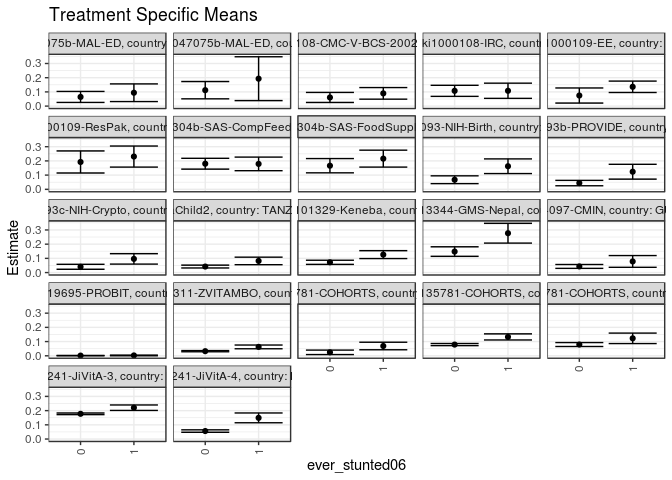

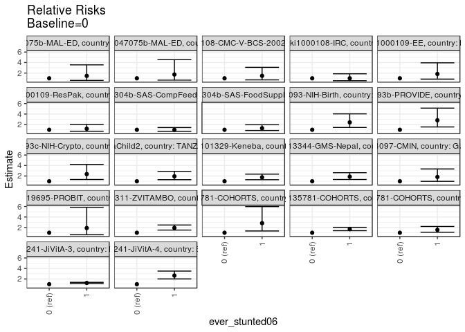

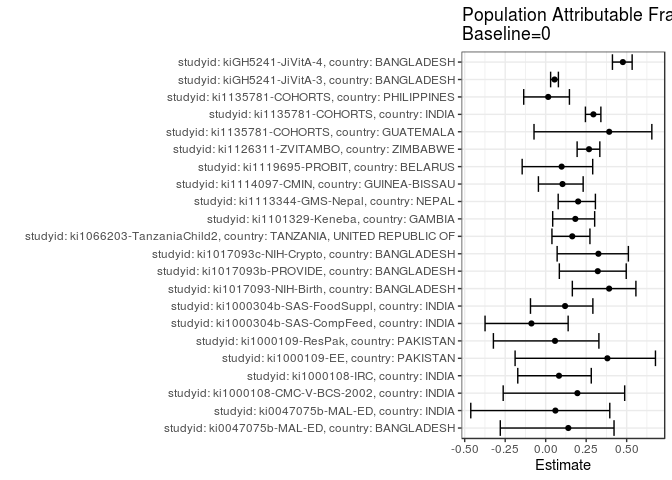

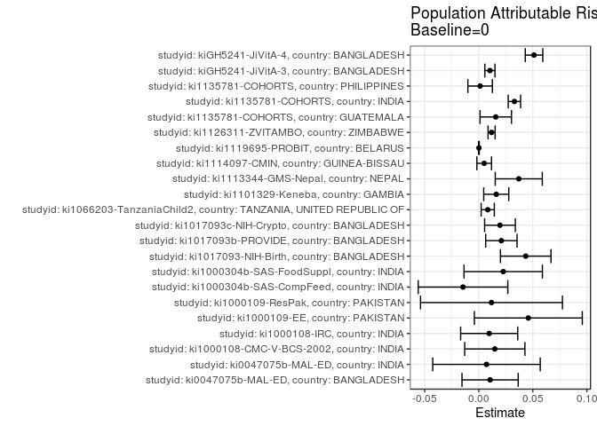

## Results Table

### Parameter: TSM

| studyid | country | intervention_level | baseline_level | estimate | ci_lower | ci_upper |
| --- | --- | --- | --- | --- | --- | --- |
| ki0047075b-MAL-ED | BANGLADESH | 0 | NA | 0.0645161 | 0.0257599 | 0.1032723 |
| ki0047075b-MAL-ED | BANGLADESH | 1 | NA | 0.0941176 | 0.0319139 | 0.1563214 |
| ki0047075b-MAL-ED | INDIA | 0 | NA | 0.1120058 | 0.0510482 | 0.1729633 |
| ki0047075b-MAL-ED | INDIA | 1 | NA | 0.1929509 | 0.0386283 | 0.3472735 |
| ki1000108-CMC-V-BCS-2002 | INDIA | 0 | NA | 0.0608559 | 0.0255798 | 0.0961319 |
| ki1000108-CMC-V-BCS-2002 | INDIA | 1 | NA | 0.0895078 | 0.0487210 | 0.1302947 |
| ki1000108-IRC | INDIA | 0 | NA | 0.1074489 | 0.0684824 | 0.1464153 |
| ki1000108-IRC | INDIA | 1 | NA | 0.1077944 | 0.0542427 | 0.1613462 |
| ki1000109-EE | PAKISTAN | 0 | NA | 0.0744681 | 0.0213251 | 0.1276111 |
| ki1000109-EE | PAKISTAN | 1 | NA | 0.1357143 | 0.0955452 | 0.1758834 |
| ki1000109-ResPak | PAKISTAN | 0 | NA | 0.1925873 | 0.1148612 | 0.2703133 |
| ki1000109-ResPak | PAKISTAN | 1 | NA | 0.2307786 | 0.1566348 | 0.3049224 |
| ki1000304b-SAS-CompFeed | INDIA | 0 | NA | 0.1802869 | 0.1421716 | 0.2184023 |
| ki1000304b-SAS-CompFeed | INDIA | 1 | NA | 0.1789872 | 0.1310923 | 0.2268820 |
| ki1000304b-SAS-FoodSuppl | INDIA | 0 | NA | 0.1664440 | 0.1162347 | 0.2166532 |
| ki1000304b-SAS-FoodSuppl | INDIA | 1 | NA | 0.2160670 | 0.1563260 | 0.2758080 |
| ki1017093-NIH-Birth | BANGLADESH | 0 | NA | 0.0674626 | 0.0401107 | 0.0948145 |
| ki1017093-NIH-Birth | BANGLADESH | 1 | NA | 0.1626185 | 0.1109969 | 0.2142400 |
| ki1017093b-PROVIDE | BANGLADESH | 0 | NA | 0.0441248 | 0.0251897 | 0.0630599 |
| ki1017093b-PROVIDE | BANGLADESH | 1 | NA | 0.1239861 | 0.0717572 | 0.1762149 |
| ki1017093c-NIH-Crypto | BANGLADESH | 0 | NA | 0.0406476 | 0.0232112 | 0.0580841 |
| ki1017093c-NIH-Crypto | BANGLADESH | 1 | NA | 0.0962986 | 0.0595709 | 0.1330264 |
| ki1066203-TanzaniaChild2 | TANZANIA, UNITED REPUBLIC OF | 0 | NA | 0.0422485 | 0.0322661 | 0.0522308 |
| ki1066203-TanzaniaChild2 | TANZANIA, UNITED REPUBLIC OF | 1 | NA | 0.0818946 | 0.0553641 | 0.1084251 |
| ki1101329-Keneba | GAMBIA | 0 | NA | 0.0721355 | 0.0573533 | 0.0869177 |
| ki1101329-Keneba | GAMBIA | 1 | NA | 0.1262368 | 0.0983600 | 0.1541137 |
| ki1113344-GMS-Nepal | NEPAL | 0 | NA | 0.1477358 | 0.1141606 | 0.1813110 |
| ki1113344-GMS-Nepal | NEPAL | 1 | NA | 0.2770555 | 0.2075467 | 0.3465643 |
| ki1114097-CMIN | GUINEA-BISSAU | 0 | NA | 0.0431773 | 0.0296052 | 0.0567495 |
| ki1114097-CMIN | GUINEA-BISSAU | 1 | NA | 0.0782956 | 0.0370862 | 0.1195049 |
| ki1119695-PROBIT | BELARUS | 0 | NA | 0.0013038 | 0.0002440 | 0.0023635 |
| ki1119695-PROBIT | BELARUS | 1 | NA | 0.0024728 | 0.0001388 | 0.0048068 |
| ki1126311-ZVITAMBO | ZIMBABWE | 0 | NA | 0.0324406 | 0.0282238 | 0.0366575 |
| ki1126311-ZVITAMBO | ZIMBABWE | 1 | NA | 0.0626236 | 0.0493983 | 0.0758489 |
| ki1135781-COHORTS | GUATEMALA | 0 | NA | 0.0243585 | 0.0086453 | 0.0400717 |
| ki1135781-COHORTS | GUATEMALA | 1 | NA | 0.0689326 | 0.0424034 | 0.0954619 |
| ki1135781-COHORTS | INDIA | 0 | NA | 0.0788897 | 0.0713542 | 0.0864252 |
| ki1135781-COHORTS | INDIA | 1 | NA | 0.1328133 | 0.1112458 | 0.1543808 |
| ki1135781-COHORTS | PHILIPPINES | 0 | NA | 0.0792039 | 0.0653156 | 0.0930923 |
| ki1135781-COHORTS | PHILIPPINES | 1 | NA | 0.1229452 | 0.0861310 | 0.1597594 |
| kiGH5241-JiVitA-3 | BANGLADESH | 0 | NA | 0.1774835 | 0.1717296 | 0.1832374 |
| kiGH5241-JiVitA-3 | BANGLADESH | 1 | NA | 0.2205353 | 0.2014009 | 0.2396696 |
| kiGH5241-JiVitA-4 | BANGLADESH | 0 | NA | 0.0561592 | 0.0474934 | 0.0648250 |
| kiGH5241-JiVitA-4 | BANGLADESH | 1 | NA | 0.1489938 | 0.1145365 | 0.1834511 |

### Parameter: E(Y)

| studyid | country | intervention_level | baseline_level | estimate | ci_lower | ci_upper |
| --- | --- | --- | --- | --- | --- | --- |
| ki0047075b-MAL-ED | BANGLADESH | NA | NA | 0.0750000 | 0.0416074 | 0.1083926 |
| ki0047075b-MAL-ED | INDIA | NA | NA | 0.1191489 | 0.0776405 | 0.1606574 |
| ki1000108-CMC-V-BCS-2002 | INDIA | NA | NA | 0.0756757 | 0.0486905 | 0.1026609 |
| ki1000108-IRC | INDIA | NA | NA | 0.1170732 | 0.0859146 | 0.1482317 |
| ki1000109-EE | PAKISTAN | NA | NA | 0.1203209 | 0.0873047 | 0.1533370 |
| ki1000109-ResPak | PAKISTAN | NA | NA | 0.2043478 | 0.1521230 | 0.2565727 |
| ki1000304b-SAS-CompFeed | INDIA | NA | NA | 0.1657061 | 0.1471754 | 0.1842367 |
| ki1000304b-SAS-FoodSuppl | INDIA | NA | NA | 0.1890547 | 0.1507312 | 0.2273783 |
| ki1017093-NIH-Birth | BANGLADESH | NA | NA | 0.1109057 | 0.0844206 | 0.1373909 |
| ki1017093b-PROVIDE | BANGLADESH | NA | NA | 0.0650407 | 0.0455353 | 0.0845460 |
| ki1017093c-NIH-Crypto | BANGLADESH | NA | NA | 0.0602740 | 0.0429977 | 0.0775502 |
| ki1066203-TanzaniaChild2 | TANZANIA, UNITED REPUBLIC OF | NA | NA | 0.0505451 | 0.0409848 | 0.0601054 |
| ki1101329-Keneba | GAMBIA | NA | NA | 0.0882993 | 0.0766987 | 0.0998998 |
| ki1113344-GMS-Nepal | NEPAL | NA | NA | 0.1847458 | 0.1534039 | 0.2160876 |
| ki1114097-CMIN | GUINEA-BISSAU | NA | NA | 0.0481809 | 0.0350130 | 0.0613488 |
| ki1119695-PROBIT | BELARUS | NA | NA | 0.0014462 | 0.0004207 | 0.0024717 |
| ki1126311-ZVITAMBO | ZIMBABWE | NA | NA | 0.0442925 | 0.0403901 | 0.0481949 |
| ki1135781-COHORTS | GUATEMALA | NA | NA | 0.0400782 | 0.0280529 | 0.0521035 |
| ki1135781-COHORTS | INDIA | NA | NA | 0.1118526 | 0.1044114 | 0.1192938 |
| ki1135781-COHORTS | PHILIPPINES | NA | NA | 0.0804557 | 0.0703953 | 0.0905161 |
| kiGH5241-JiVitA-3 | BANGLADESH | NA | NA | 0.1877787 | 0.1812440 | 0.1943134 |
| kiGH5241-JiVitA-4 | BANGLADESH | NA | NA | 0.1072855 | 0.0967458 | 0.1178252 |

### Parameter: RR

| studyid | country | intervention_level | baseline_level | estimate | ci_lower | ci_upper |
| --- | --- | --- | --- | --- | --- | --- |
| ki0047075b-MAL-ED | BANGLADESH | 0 | 0 | 1.0000000 | 1.0000000 | 1.000000 |
| ki0047075b-MAL-ED | BANGLADESH | 1 | 0 | 1.4588235 | 0.5972043 | 3.563548 |
| ki0047075b-MAL-ED | INDIA | 0 | 0 | 1.0000000 | 1.0000000 | 1.000000 |
| ki0047075b-MAL-ED | INDIA | 1 | 0 | 1.7226870 | 0.6531139 | 4.543848 |
| ki1000108-CMC-V-BCS-2002 | INDIA | 0 | 0 | 1.0000000 | 1.0000000 | 1.000000 |
| ki1000108-CMC-V-BCS-2002 | INDIA | 1 | 0 | 1.4708172 | 0.7017649 | 3.082661 |
| ki1000108-IRC | INDIA | 0 | 0 | 1.0000000 | 1.0000000 | 1.000000 |
| ki1000108-IRC | INDIA | 1 | 0 | 1.0032160 | 0.5415345 | 1.858501 |
| ki1000109-EE | PAKISTAN | 0 | 0 | 1.0000000 | 1.0000000 | 1.000000 |
| ki1000109-EE | PAKISTAN | 1 | 0 | 1.8224490 | 0.8416430 | 3.946234 |
| ki1000109-ResPak | PAKISTAN | 0 | 0 | 1.0000000 | 1.0000000 | 1.000000 |
| ki1000109-ResPak | PAKISTAN | 1 | 0 | 1.1983067 | 0.7105913 | 2.020766 |
| ki1000304b-SAS-CompFeed | INDIA | 0 | 0 | 1.0000000 | 1.0000000 | 1.000000 |
| ki1000304b-SAS-CompFeed | INDIA | 1 | 0 | 0.9927905 | 0.6910781 | 1.426225 |
| ki1000304b-SAS-FoodSuppl | INDIA | 0 | 0 | 1.0000000 | 1.0000000 | 1.000000 |
| ki1000304b-SAS-FoodSuppl | INDIA | 1 | 0 | 1.2981366 | 0.8621435 | 1.954615 |
| ki1017093-NIH-Birth | BANGLADESH | 0 | 0 | 1.0000000 | 1.0000000 | 1.000000 |
| ki1017093-NIH-Birth | BANGLADESH | 1 | 0 | 2.4104992 | 1.4397570 | 4.035755 |
| ki1017093b-PROVIDE | BANGLADESH | 0 | 0 | 1.0000000 | 1.0000000 | 1.000000 |
| ki1017093b-PROVIDE | BANGLADESH | 1 | 0 | 2.8098950 | 1.5392411 | 5.129482 |
| ki1017093c-NIH-Crypto | BANGLADESH | 0 | 0 | 1.0000000 | 1.0000000 | 1.000000 |
| ki1017093c-NIH-Crypto | BANGLADESH | 1 | 0 | 2.3691071 | 1.3336339 | 4.208553 |
| ki1066203-TanzaniaChild2 | TANZANIA, UNITED REPUBLIC OF | 0 | 0 | 1.0000000 | 1.0000000 | 1.000000 |
| ki1066203-TanzaniaChild2 | TANZANIA, UNITED REPUBLIC OF | 1 | 0 | 1.9384042 | 1.2976531 | 2.895544 |
| ki1101329-Keneba | GAMBIA | 0 | 0 | 1.0000000 | 1.0000000 | 1.000000 |
| ki1101329-Keneba | GAMBIA | 1 | 0 | 1.7499957 | 1.2964581 | 2.362194 |
| ki1113344-GMS-Nepal | NEPAL | 0 | 0 | 1.0000000 | 1.0000000 | 1.000000 |
| ki1113344-GMS-Nepal | NEPAL | 1 | 0 | 1.8753446 | 1.3389918 | 2.626541 |
| ki1114097-CMIN | GUINEA-BISSAU | 0 | 0 | 1.0000000 | 1.0000000 | 1.000000 |
| ki1114097-CMIN | GUINEA-BISSAU | 1 | 0 | 1.8133482 | 0.9833722 | 3.343832 |
| ki1119695-PROBIT | BELARUS | 0 | 0 | 1.0000000 | 1.0000000 | 1.000000 |
| ki1119695-PROBIT | BELARUS | 1 | 0 | 1.8966370 | 0.6161343 | 5.838390 |
| ki1126311-ZVITAMBO | ZIMBABWE | 0 | 0 | 1.0000000 | 1.0000000 | 1.000000 |
| ki1126311-ZVITAMBO | ZIMBABWE | 1 | 0 | 1.9304070 | 1.5066464 | 2.473355 |
| ki1135781-COHORTS | GUATEMALA | 0 | 0 | 1.0000000 | 1.0000000 | 1.000000 |
| ki1135781-COHORTS | GUATEMALA | 1 | 0 | 2.8299184 | 1.3380174 | 5.985302 |
| ki1135781-COHORTS | INDIA | 0 | 0 | 1.0000000 | 1.0000000 | 1.000000 |
| ki1135781-COHORTS | INDIA | 1 | 0 | 1.6835318 | 1.3958453 | 2.030511 |
| ki1135781-COHORTS | PHILIPPINES | 0 | 0 | 1.0000000 | 1.0000000 | 1.000000 |
| ki1135781-COHORTS | PHILIPPINES | 1 | 0 | 1.5522612 | 1.0984483 | 2.193562 |
| kiGH5241-JiVitA-3 | BANGLADESH | 0 | 0 | 1.0000000 | 1.0000000 | 1.000000 |
| kiGH5241-JiVitA-3 | BANGLADESH | 1 | 0 | 1.2425675 | 1.1353630 | 1.359895 |
| kiGH5241-JiVitA-4 | BANGLADESH | 0 | 0 | 1.0000000 | 1.0000000 | 1.000000 |
| kiGH5241-JiVitA-4 | BANGLADESH | 1 | 0 | 2.6530609 | 2.0097600 | 3.502275 |

### Parameter: PAR

| studyid | country | intervention_level | baseline_level | estimate | ci_lower | ci_upper |
| --- | --- | --- | --- | --- | --- | --- |
| ki0047075b-MAL-ED | BANGLADESH | 0 | NA | 0.0104839 | -0.0155348 | 0.0365026 |
| ki0047075b-MAL-ED | INDIA | 0 | NA | 0.0071432 | -0.0425902 | 0.0568765 |
| ki1000108-CMC-V-BCS-2002 | INDIA | 0 | NA | 0.0148198 | -0.0130396 | 0.0426792 |
| ki1000108-IRC | INDIA | 0 | NA | 0.0096243 | -0.0167854 | 0.0360339 |
| ki1000109-EE | PAKISTAN | 0 | NA | 0.0458528 | -0.0040933 | 0.0957988 |
| ki1000109-ResPak | PAKISTAN | 0 | NA | 0.0117605 | -0.0539070 | 0.0774281 |
| ki1000304b-SAS-CompFeed | INDIA | 0 | NA | -0.0145809 | -0.0560324 | 0.0268706 |
| ki1000304b-SAS-FoodSuppl | INDIA | 0 | NA | 0.0226108 | -0.0136630 | 0.0588845 |
| ki1017093-NIH-Birth | BANGLADESH | 0 | NA | 0.0434432 | 0.0200715 | 0.0668148 |
| ki1017093b-PROVIDE | BANGLADESH | 0 | NA | 0.0209158 | 0.0064059 | 0.0354257 |
| ki1017093c-NIH-Crypto | BANGLADESH | 0 | NA | 0.0196263 | 0.0054077 | 0.0338450 |
| ki1066203-TanzaniaChild2 | TANZANIA, UNITED REPUBLIC OF | 0 | NA | 0.0082966 | 0.0021956 | 0.0143976 |
| ki1101329-Keneba | GAMBIA | 0 | NA | 0.0161638 | 0.0045630 | 0.0277645 |
| ki1113344-GMS-Nepal | NEPAL | 0 | NA | 0.0370100 | 0.0152395 | 0.0587804 |
| ki1114097-CMIN | GUINEA-BISSAU | 0 | NA | 0.0050036 | -0.0017558 | 0.0117630 |
| ki1119695-PROBIT | BELARUS | 0 | NA | 0.0001424 | -0.0001556 | 0.0004405 |
| ki1126311-ZVITAMBO | ZIMBABWE | 0 | NA | 0.0118519 | 0.0085814 | 0.0151225 |
| ki1135781-COHORTS | GUATEMALA | 0 | NA | 0.0157197 | 0.0011661 | 0.0302732 |
| ki1135781-COHORTS | INDIA | 0 | NA | 0.0329629 | 0.0272298 | 0.0386960 |
| ki1135781-COHORTS | PHILIPPINES | 0 | NA | 0.0012517 | -0.0100904 | 0.0125939 |
| kiGH5241-JiVitA-3 | BANGLADESH | 0 | NA | 0.0102952 | 0.0056158 | 0.0149747 |
| kiGH5241-JiVitA-4 | BANGLADESH | 0 | NA | 0.0511263 | 0.0430235 | 0.0592292 |

### Parameter: PAF

| studyid | country | intervention_level | baseline_level | estimate | ci_lower | ci_upper |
| --- | --- | --- | --- | --- | --- | --- |
| ki0047075b-MAL-ED | BANGLADESH | 0 | NA | 0.1397849 | -0.2802981 | 0.4220331 |
| ki0047075b-MAL-ED | INDIA | 0 | NA | 0.0599517 | -0.4625276 | 0.3957783 |
| ki1000108-CMC-V-BCS-2002 | INDIA | 0 | NA | 0.1958334 | -0.2624025 | 0.4877355 |
| ki1000108-IRC | INDIA | 0 | NA | 0.0822074 | -0.1723219 | 0.2814744 |
| ki1000109-EE | PAKISTAN | 0 | NA | 0.3810875 | -0.1888599 | 0.6777983 |
| ki1000109-ResPak | PAKISTAN | 0 | NA | 0.0575516 | -0.3228406 | 0.3285593 |
| ki1000304b-SAS-CompFeed | INDIA | 0 | NA | -0.0879925 | -0.3743571 | 0.1387044 |
| ki1000304b-SAS-FoodSuppl | INDIA | 0 | NA | 0.1195990 | -0.0938287 | 0.2913827 |
| ki1017093-NIH-Birth | BANGLADESH | 0 | NA | 0.3917125 | 0.1645789 | 0.5570932 |
| ki1017093b-PROVIDE | BANGLADESH | 0 | NA | 0.3215810 | 0.0843097 | 0.4973712 |
| ki1017093c-NIH-Crypto | BANGLADESH | 0 | NA | 0.3256185 | 0.0707566 | 0.5105800 |
| ki1066203-TanzaniaChild2 | TANZANIA, UNITED REPUBLIC OF | 0 | NA | 0.1641430 | 0.0386432 | 0.2732595 |
| ki1101329-Keneba | GAMBIA | 0 | NA | 0.1830566 | 0.0432719 | 0.3024177 |
| ki1113344-GMS-Nepal | NEPAL | 0 | NA | 0.2003293 | 0.0772254 | 0.3070103 |
| ki1114097-CMIN | GUINEA-BISSAU | 0 | NA | 0.1038499 | -0.0448478 | 0.2313857 |
| ki1119695-PROBIT | BELARUS | 0 | NA | 0.0984898 | -0.1451996 | 0.2903240 |
| ki1126311-ZVITAMBO | ZIMBABWE | 0 | NA | 0.2675824 | 0.1941488 | 0.3343243 |
| ki1135781-COHORTS | GUATEMALA | 0 | NA | 0.3922251 | -0.0720450 | 0.6554339 |
| ki1135781-COHORTS | INDIA | 0 | NA | 0.2946994 | 0.2454018 | 0.3407764 |
| ki1135781-COHORTS | PHILIPPINES | 0 | NA | 0.0155581 | -0.1356605 | 0.1466412 |
| kiGH5241-JiVitA-3 | BANGLADESH | 0 | NA | 0.0548264 | 0.0305259 | 0.0785177 |
| kiGH5241-JiVitA-4 | BANGLADESH | 0 | NA | 0.4765444 | 0.4121563 | 0.5338799 |